# Chapter 2 – End-to-end Machine Learning project

# Vorbereitung

#### Dieses Noteboook wurde erstellt von Aurelien Geron. Es gehört zu dessen Buch "Hands-on Machine Learning with Scikit-learn,Keras and Tensorflow ".

Das Original-Notebook kann man finden unter https://github.com/ageron/handson-ml2/blob/master/02_end_to_end_machine_learning_project.ipynb

Das Notebook wurde für Unterrichtszwecke verändert und kommentiert von Elisabeth Staegemann

```python
#Angeben, unter welchen Systemvoraussetzungen das Notebook läuft

import sys
assert sys.version_info >= (3, 7)


import sklearn
assert sklearn.__version__ >= "1.2"
import numpy as np
import pandas as pd
import matplotlib.pyplot as plt
import pickle
```

#### Schreibe eine Funktion zum einfachen Abspeichern von Bildern

```python
# extra code – code to save the figures as high-res PNGs for the book
# erzeugt auch den images-Ordner, falls der nicht existiert

from pathlib import Path
import pickle

IMAGES_PATH = Path() / "images"
IMAGES_PATH.mkdir(parents=True, exist_ok=True)

def save_fig(fig_id, tight_layout=True, fig_extension="png", resolution=300):
    path = IMAGES_PATH / f"{fig_id}.{fig_extension}"
    if tight_layout:
        plt.tight_layout()
    plt.savefig(path, format=fig_extension, dpi=resolution)
```

#### Schreibe eine Funktion für den einfachen Download

```python
from pathlib import Path
import tarfile
import urllib.request

def load_housing_data(url,ordner_name,csv_name):
    ordner = Path(ordner_name)
    tarball_path = ordner / Path(url).name # der  Filename des Archivs
    csv_file = ordner / Path(csv_name)

    if not tarball_path.is_file():
        ordner.mkdir(parents=True, exist_ok=True)
        urllib.request.urlretrieve(url, tarball_path)

    csv_file = ordner / "housing" / csv_name
    # der tarball erzeugt beim Auspacken den Ordnernamen "housing"
    # das muss man wissen

    if not csv_file.is_file():
        with tarfile.open(tarball_path) as housing_tarball:
            housing_tarball.extractall(path=ordner.name)

    return pd.read_csv(csv_file)
```

# Überblick über die Daten

## Herunterladen

*Welcome to Machine Learning Housing Corp.! **_**Your task is to predict median house values in Californian districts, given a number of features from these districts.*

```python
housing_gesamt \
= load_housing_data(url="https://github.com/ageron/data/raw/main/housing.tgz",
                    ordner_name="datasets", csv_name="housing.csv")
#print(type(housing_gesamt))
```

## Take a Quick Look at the Data Structure

```python
housing_gesamt.head(10)
```

|  | longitude | latitude | housing_median_age | total_rooms | total_bedrooms | population | households | median_income | median_house_value | ocean_proximity |
| --- | --- | --- | --- | --- | --- | --- | --- | --- | --- | --- |
| 0 | -122.23 | 37.88 | 41.0 | 880.0 | 129.0 | 322.0 | 126.0 | 8.3252 | 452600.0 | NEAR BAY |
| 1 | -122.22 | 37.86 | 21.0 | 7099.0 | 1106.0 | 2401.0 | 1138.0 | 8.3014 | 358500.0 | NEAR BAY |
| 2 | -122.24 | 37.85 | 52.0 | 1467.0 | 190.0 | 496.0 | 177.0 | 7.2574 | 352100.0 | NEAR BAY |
| 3 | -122.25 | 37.85 | 52.0 | 1274.0 | 235.0 | 558.0 | 219.0 | 5.6431 | 341300.0 | NEAR BAY |
| 4 | -122.25 | 37.85 | 52.0 | 1627.0 | 280.0 | 565.0 | 259.0 | 3.8462 | 342200.0 | NEAR BAY |
| 5 | -122.25 | 37.85 | 52.0 | 919.0 | 213.0 | 413.0 | 193.0 | 4.0368 | 269700.0 | NEAR BAY |
| 6 | -122.25 | 37.84 | 52.0 | 2535.0 | 489.0 | 1094.0 | 514.0 | 3.6591 | 299200.0 | NEAR BAY |
| 7 | -122.25 | 37.84 | 52.0 | 3104.0 | 687.0 | 1157.0 | 647.0 | 3.1200 | 241400.0 | NEAR BAY |
| 8 | -122.26 | 37.84 | 42.0 | 2555.0 | 665.0 | 1206.0 | 595.0 | 2.0804 | 226700.0 | NEAR BAY |
| 9 | -122.25 | 37.84 | 52.0 | 3549.0 | 707.0 | 1551.0 | 714.0 | 3.6912 | 261100.0 | NEAR BAY |

```python
housing_gesamt.info()
```

```
<class 'pandas.core.frame.DataFrame'>
RangeIndex: 20640 entries, 0 to 20639
Data columns (total 10 columns):
 #   Column              Non-Null Count  Dtype
---  ------              --------------  -----
 0   longitude           20640 non-null  float64
 1   latitude            20640 non-null  float64
 2   housing_median_age  20640 non-null  float64
 3   total_rooms         20640 non-null  float64
 4   total_bedrooms      20433 non-null  float64
 5   population          20640 non-null  float64
 6   households          20640 non-null  float64
 7   median_income       20640 non-null  float64
 8   median_house_value  20640 non-null  float64
 9   ocean_proximity     20640 non-null  object
dtypes: float64(9), object(1)
memory usage: 1.6+ MB
```

### Inhalte der Object-Spalte

```python
# Was steht denn wohl in der Spalte, die den Typ "object" hat?
housing_gesamt["ocean_proximity"].value_counts()
```

```
<1H OCEAN     9136
INLAND        6551
NEAR OCEAN    2658
NEAR BAY      2290
ISLAND           5
Name: ocean_proximity, dtype: int64
```

### Inhalte der Numerischen Spalten

```python
housing_gesamt.describe()
```

|  | longitude | latitude | housing_median_age | total_rooms | total_bedrooms | population | households | median_income | median_house_value |
| --- | --- | --- | --- | --- | --- | --- | --- | --- | --- |
| count | 20640.000000 | 20640.000000 | 20640.000000 | 20640.000000 | 20433.000000 | 20640.000000 | 20640.000000 | 20640.000000 | 20640.000000 |
| mean | -119.569704 | 35.631861 | 28.639486 | 2635.763081 | 537.870553 | 1425.476744 | 499.539680 | 3.870671 | 206855.816909 |
| std | 2.003532 | 2.135952 | 12.585558 | 2181.615252 | 421.385070 | 1132.462122 | 382.329753 | 1.899822 | 115395.615874 |
| min | -124.350000 | 32.540000 | 1.000000 | 2.000000 | 1.000000 | 3.000000 | 1.000000 | 0.499900 | 14999.000000 |
| 25% | -121.800000 | 33.930000 | 18.000000 | 1447.750000 | 296.000000 | 787.000000 | 280.000000 | 2.563400 | 119600.000000 |
| 50% | -118.490000 | 34.260000 | 29.000000 | 2127.000000 | 435.000000 | 1166.000000 | 409.000000 | 3.534800 | 179700.000000 |
| 75% | -118.010000 | 37.710000 | 37.000000 | 3148.000000 | 647.000000 | 1725.000000 | 605.000000 | 4.743250 | 264725.000000 |
| max | -114.310000 | 41.950000 | 52.000000 | 39320.000000 | 6445.000000 | 35682.000000 | 6082.000000 | 15.000100 | 500001.000000 |

### Histogramme

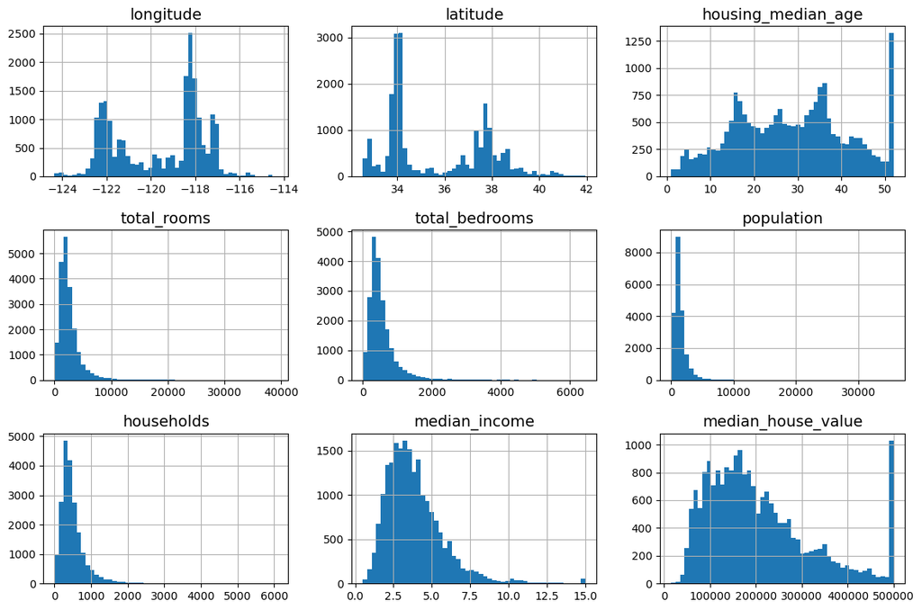

```python
# extra code – the next 5 lines define the default font sizes
plt.rc('font', size=14)
plt.rc('axes', labelsize=14, titlesize=14)
plt.rc('legend', fontsize=14)
plt.rc('xtick', labelsize=10)
plt.rc('ytick', labelsize=10)

housing_gesamt.hist(bins=50, figsize=(12, 8))
save_fig("attribute_histogram_plots")  # extra code
plt.show()
```

```python
# Genauer Hinschauen
datensatz_truncated = housing_gesamt[housing_gesamt["median_house_value"]>500000]
print("Die Anzahl der Zeilen und Spalten, wo der Preis > 500_000\n",
      datensatz_truncated.shape)
```

```
Die Anzahl der Zeilen und Spalten, wo der Preis > 500_000
 (965, 10)
```

# Create a Test Set

To ensure that this notebook's outputs remain the same every time we run it, we need to set the random seed:

Sadly, this won't guarantee that this notebook will output exactly the same results as in the book, since there are other possible sources of variation. The most important is the fact that algorithms get tweaked over time when libraries evolve. So please tolerate some minor differences: hopefully, most of the outputs should be the same, or at least in the right ballpark.

```python
# Daten in Trainingsmenge und Testmenge aufteilen
# Testmenge soll repräsentativ sein
#                          (Verallgemeinerung des Modells muss möglich sein)
#Frage: Wie groß soll die Testmenge sein?
```

#### Variante 1: Trennungsfunktion selbst schreiben

```python
# Einfaches Beispiel: kann getrennt vom Rest behandelt werden
```

```python
# Code-Erklärung 1
# Das Ausgeben von Spalten, Zeilen und Zellen bei einem Pandas-Dataframe
```

```python
data =pd.DataFrame([[1,2,101],[3,4,102],[5,6,103],[7,8,104],[9,10,105],[11,12,106],
                [13,14,107],[15,16,108],[17,18,109],[19,20,101]], columns=["A","B","C"],index=["zeile1","zeile2","zeile3","zeile4","zeile5","zeile6","zeile7","zeile8","zeile9","zeile10",])
data
```

|  | A | B | C |
| --- | --- | --- | --- |
| zeile1 | 1 | 2 | 101 |
| zeile2 | 3 | 4 | 102 |
| zeile3 | 5 | 6 | 103 |
| zeile4 | 7 | 8 | 104 |
| zeile5 | 9 | 10 | 105 |
| zeile6 | 11 | 12 | 106 |
| zeile7 | 13 | 14 | 107 |
| zeile8 | 15 | 16 | 108 |
| zeile9 | 17 | 18 | 109 |
| zeile10 | 19 | 20 | 101 |

```python
print("Angabe von Inhalten mit Nummern, wie bei Listen")
print(data.iloc[     0:5,            0:1])
data.iloc      [     [0,1,2,3,4],    0 ]
data.iloc[0,1]
```

```
Angabe von Inhalten mit Nummern, wie bei Listen
        A
zeile1  1
zeile2  3
zeile3  5
zeile4  7
zeile5  9
```

```
2
```

```python
print("erste Zeile des pandas-Dataframes")
print(data.loc["zeile1"],end="\n\n\n")


print("die beiden AnfangsZeilen des pandas-Dataframes\n",data.loc[["zeile1","zeile2"]])
```

```
erste Zeile des pandas-Dataframes
A      1
B      2
C    101
Name: zeile1, dtype: int64


die beiden AnfangsZeilen des pandas-Dataframes
         A  B    C
zeile1  1  2  101
zeile2  3  4  102
```

```python
print("erste Spalte des pandas-Dataframes")
print(data.loc["zeile1"],end="\n\n\n")

print(data["A"],end="\n\n\n")
print("die beiden Anfangsspalten des pandas-Dataframes\n",data[["A","B"]])
type(data["A"])
```

```
erste Spalte des pandas-Dataframes
A      1
B      2
C    101
Name: zeile1, dtype: int64


zeile1      1
zeile2      3
zeile3      5
zeile4      7
zeile5      9
zeile6     11
zeile7     13
zeile8     15
zeile9     17
zeile10    19
Name: A, dtype: int64


die beiden Anfangsspalten des pandas-Dataframes
           A   B
zeile1    1   2
zeile2    3   4
zeile3    5   6
zeile4    7   8
zeile5    9  10
zeile6   11  12
zeile7   13  14
zeile8   15  16
zeile9   17  18
zeile10  19  20
```

```
pandas.core.series.Series
```

```python
# Code-Erklärung 2
```

```python
# In dieser Zelle nach und nach die Zeilen aus dem Kommentar herausnehmen
test_set = ""
# Permutation 1,2,3,4------------4,2,1,3---4,3,2,1--1,4,2,3
print("Größe der Gesamtmenge:\t",len(data))
print(len(data))

np.random.seed(42)
shuffled_indices = np.random.permutation(len(data))


print("Permutation der Zeilenindizes:\t",shuffled_indices)
test_set_size = int(len(data) * 0.2)
print("Größe der Testmenge:\t",test_set_size)

test_indices = shuffled_indices[:test_set_size]
test_indices = shuffled_indices[:2]
print("Indizes für die Testmenge:\t",test_indices)
test_set = data.iloc[test_indices]
print("Testdaten")
test_set
```

```
Größe der Gesamtmenge:	 10
10
Permutation der Zeilenindizes:	 [8 1 5 0 7 2 9 4 3 6]
Größe der Testmenge:	 2
Indizes für die Testmenge:	 [8 1]
Testdaten
```

[output not shown]

```python
# echter Code
```

```python
np.random.seed(42)
```

```python
import numpy as np

def shuffle_and_split_data(data, test_ratio):

    shuffled_indices = np.random.permutation(len(data))#20_000
    test_set_size = int(len(data) * test_ratio)#4_000
    test_indices = shuffled_indices[:test_set_size]#[0:4_000],1,3,5...
    train_indices = shuffled_indices[test_set_size:]#2,4,6...
    return (data.iloc[train_indices], data.iloc[test_indices])
```

```python
#Überprüfen, ob die Länge richtig ist
print("alle Datensätze:",len(housing_gesamt))
print("Testset:",len(test_set) )
# alles so groß, wie erwartet
```

```
alle Datensätze: 20640
Testset: 2
```

```python
#test_set.head()
```

#### Variante 2:Trennungsfunktion selbst schreiben, dabei Orientierung an einer ID-Spalte

```python
# z.B. ID-Spalte=Datumsangabe, Trennung in frühere und spätere Daten
# z.B. ID-Spalte =Kombination aus Längengrad und Breitengrad,
#                 Training mit den nördlichen Häusern, Test mit den südlichen Häusern
```

#### Variante 3: die vordefinierte Funktion aus scikit-learn benutzen

```python
from sklearn.model_selection import train_test_split

train_set, test_set = train_test_split(housing_gesamt, test_size=0.2, random_state=42)
train_set.head()
```

|  | longitude | latitude | housing_median_age | total_rooms | total_bedrooms | population | households | median_income | median_house_value | ocean_proximity |
| --- | --- | --- | --- | --- | --- | --- | --- | --- | --- | --- |
| 14196 | -117.22 | 32.75 | 34.0 | 6001.0 | 1111.0 | 2654.0 | 1072.0 | 4.5878 | 291000.0 | NEAR OCEAN |
| 8267 | -117.03 | 32.69 | 10.0 | 901.0 | 163.0 | 698.0 | 167.0 | 4.6648 | 156100.0 | NEAR OCEAN |
| 17445 | -122.27 | 37.74 | 28.0 | 6909.0 | 1554.0 | 2974.0 | 1484.0 | 3.6875 | 353900.0 | NEAR BAY |
| 14265 | -121.82 | 37.25 | 25.0 | 4021.0 | 634.0 | 2178.0 | 650.0 | 5.1663 | 241200.0 | <1H OCEAN |
| 2271 | -115.98 | 33.32 | 8.0 | 240.0 | 46.0 | 63.0 | 24.0 | 1.4688 | 53800.0 | INLAND |

```python
test_set.head()
```

|  | longitude | latitude | housing_median_age | total_rooms | total_bedrooms | population | households | median_income | median_house_value | ocean_proximity |
| --- | --- | --- | --- | --- | --- | --- | --- | --- | --- | --- |
| 20046 | -122.38 | 40.67 | 10.0 | 2281.0 | 444.0 | 1274.0 | 438.0 | 2.2120 | 65600.0 | INLAND |
| 3024 | -118.37 | 33.83 | 35.0 | 1207.0 | 207.0 | 601.0 | 213.0 | 4.7308 | 353400.0 | <1H OCEAN |
| 15663 | -117.24 | 32.72 | 39.0 | 3089.0 | 431.0 | 1175.0 | 432.0 | 7.5925 | 466700.0 | NEAR OCEAN |
| 20484 | -118.44 | 34.05 | 18.0 | 4780.0 | 1192.0 | 1886.0 | 1036.0 | 4.4674 | 500001.0 | <1H OCEAN |
| 9814 | -118.44 | 34.18 | 33.0 | 2127.0 | 414.0 | 1056.0 | 391.0 | 4.3750 | 286100.0 | <1H OCEAN |

#### Variante 4: Stratifizierte Trennung von Test und Trainingsmenge

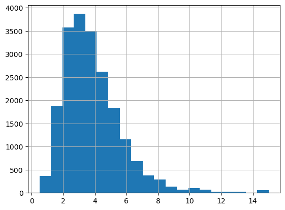

```python
# Bevor stratifiziert wird,
# muss man kontinuierliche Daten in Kategorien umwandeln.
# Reicht es aus , die Kategorien eines normalen Histogramms zu wählen?
# Bei diesem Beispiel sicher nicht.
housing_gesamt["median_income"].hist(bins=20)
```

```python
# Wir legen die Kategorien mit Hilfe der pandas-Funktion cut fest.
# Die Grenzen bestimmen wir selbst
housing_gesamt["income_cat"] = pd.cut(housing_gesamt["median_income"],
                               bins=[0., 1.5, 3.0, 4.5, 6., np.inf],
                               labels=["arm", "gering", "mittel", "hoch", "reich"])
```

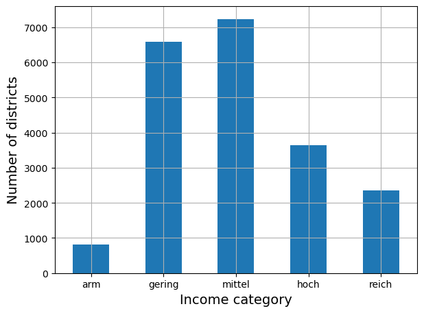

```python
# Wir zeichnen, wieviele Elemente zu jeder Kategorie gehören.
housing_gesamt["income_cat"].value_counts().sort_index().plot.bar(rot=0, grid=True)

plt.xlabel("Income category")
plt.ylabel("Number of districts")
save_fig("housing_income_cat_bar_plot")  # extra code
plt.show()
```

#### Variante 4a: mehrere stratifizierte Splits auf einmal erzeugen: "doppelt hält besser"

```python
from sklearn.model_selection import StratifiedShuffleSplit

splitter = StratifiedShuffleSplit(n_splits=10, test_size=0.2, random_state=42)
strat_splits = []
for train_index, test_index in splitter.split(housing_gesamt, housing_gesamt["income_cat"]):
    strat_train_set_n = housing_gesamt.loc[train_index]
    strat_test_set_n = housing_gesamt.loc[test_index]
    strat_splits.append([strat_train_set_n, strat_test_set_n])
```

```python
strat_train_set, strat_test_set = strat_splits[0]
```

#### Variante 4b: ein einfacher stratifizierter split kann auch mit train_test_split erreicht werden

```python
strat_train_set, strat_test_set = train_test_split(
    housing_gesamt, test_size=0.2,
    stratify=housing_gesamt["income_cat"],
    random_state=42)
"""
train_test_split(Datensatz, Zielspalte, stratify=Zielspalte)
train_test_split(X, y, stratify=y)
# von jeder Kategorie der Zielspalte ist der richtige Prozentsatz enthalten
train_test_split(X, y, stratify=X.iloc[:,0])
# von der ersten Datenspalte ist der richtige Prozentsatz enthalten
# weil die erste Spalte wichtig ist für die Voraussage
"""
```

```
'\ntrain_test_split(Datensatz, Zielspalte, stratify=Zielspalte)\ntrain_test_split(X, y, stratify=y) \n# von jeder Kategorie der Zielspalte ist der richtige Prozentsatz enthalten\ntrain_test_split(X, y, stratify=X.iloc[:,0])\n# von der ersten Datenspalte ist der richtige Prozentsatz enthalten\n# weil…
```

#### Den Effekt der Stratifizierung überprüfen

```python
strat_test_set["income_cat"].value_counts()    / len(strat_test_set)
```

```
mittel    0.350533
gering    0.318798
hoch      0.176357
reich     0.114341
arm       0.039971
Name: income_cat, dtype: float64
```

```python
# extra code – computes the data for Figure 2–10

def income_cat_proportions(data):
    return data["income_cat"].value_counts() / len(data)

train_set, test_set = train_test_split(housing_gesamt, test_size=0.2, random_state=42)

compare_props = pd.DataFrame({
    "Overall %": income_cat_proportions(housing_gesamt),
    "Stratified %": income_cat_proportions(strat_test_set),
    "Random %": income_cat_proportions(test_set),
}).sort_index()
compare_props.index.name = "Income Category"
compare_props["Strat. Error %"] = (compare_props["Stratified %"] /
                                   compare_props["Overall %"] - 1)
compare_props["Rand. Error %"] = (compare_props["Random %"] /
                                  compare_props["Overall %"] - 1)
(compare_props * 100).round(2)
```

| Income Category | Overall % | Stratified % | Random % | Strat. Error % | Rand. Error % |
| --- | --- | --- | --- | --- | --- |
| arm | 3.98 | 4.00 | 4.24 | 0.36 | 6.45 |
| gering | 31.88 | 31.88 | 30.74 | -0.02 | -3.59 |
| mittel | 35.06 | 35.05 | 34.52 | -0.01 | -1.53 |
| hoch | 17.63 | 17.64 | 18.41 | 0.03 | 4.42 |
| reich | 11.44 | 11.43 | 12.09 | -0.08 | 5.63 |

```python
for set_ in (strat_train_set, strat_test_set):
    set_.drop("income_cat", axis=1, inplace=True)
```

# Discover and Visualize the Data to Gain Insights

```python
housing = strat_train_set.copy()
# ab hier bedeutet housing die Trainingsmenge
```

## Visualizing Geographical Data

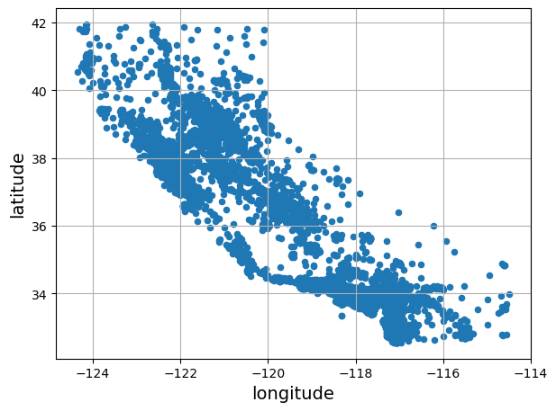

```python
housing.plot(kind="scatter", x="longitude", y="latitude", grid=True)
save_fig("bad_visualization_plot")  # extra code
plt.show()
```

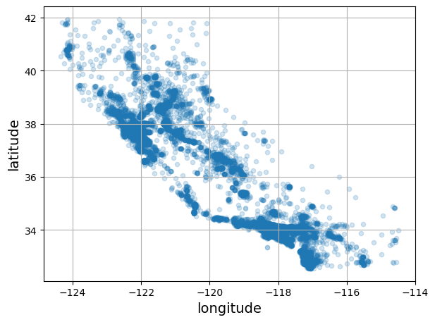

```python
housing.plot(kind="scatter", x="longitude", y="latitude", grid=True, alpha=0.2)
save_fig("better_visualization_plot")  # extra code
plt.show()
```

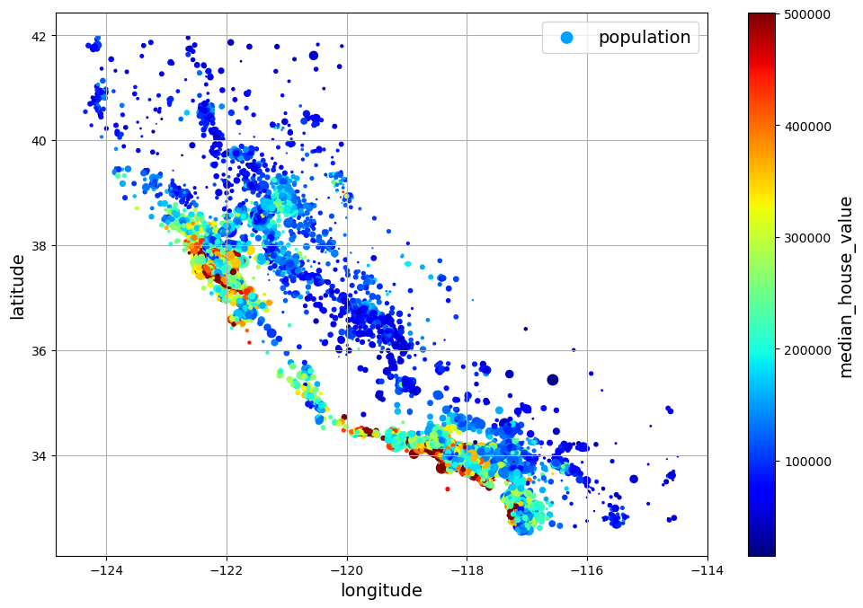

```python
housing.plot(kind="scatter", x="longitude", y="latitude", grid=True,
             s=housing["population"] / 100, label="population",
             c="median_house_value", cmap="jet", colorbar=True,
             legend=True, figsize=(10, 7)
             , sharex=False
            )
save_fig("housing_prices_scatterplot")  # extra code
plt.show()
```

The argument `sharex=False` fixes a display bug: without it, the x-axis values and label are not displayed (see: https://github.com/pandas-dev/pandas/issues/10611).

The next cell generates the first figure in the chapter (this code is not in the book). It's just a beautified version of the previous figure, with an image of California added in the background, nicer label names and no grid.

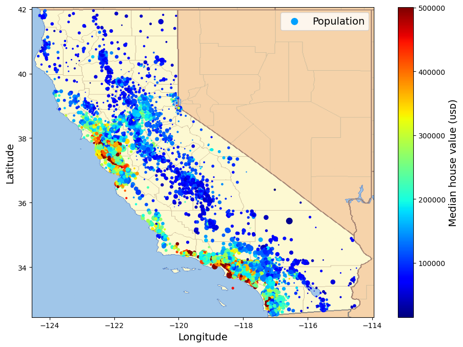

```python
# extra code – this cell generates the first figure in the chapter

# Download the California image
filename = "california.png"
if not (IMAGES_PATH / filename).is_file():
    homl3_root = "https://github.com/ageron/handson-ml3/raw/main/"
    url = homl3_root + "images/end_to_end_project/" + filename
    print("Downloading", filename)
    urllib.request.urlretrieve(url, IMAGES_PATH / filename)

housing_renamed = housing.rename(columns={
    "latitude": "Latitude", "longitude": "Longitude",
    "population": "Population",
    "median_house_value": "Median house value (ᴜsᴅ)"})
housing_renamed.plot(
             kind="scatter", x="Longitude", y="Latitude",
             s=housing_renamed["Population"] / 100, label="Population",
             c="Median house value (ᴜsᴅ)", cmap="jet", colorbar=True,
             legend=True, sharex=False, figsize=(10, 7))

california_img = plt.imread(IMAGES_PATH / filename)
axis = -124.55, -113.95, 32.45, 42.05
plt.axis(axis)
plt.imshow(california_img, extent=axis)

save_fig("california_housing_prices_plot")
plt.show()
```

## Looking for Correlations

### Korrelationsberechnung

###### Beziehungen zwischen den Spalten feststellen

$r=\frac{\sum{(x-\bar{x})(y-\bar{y})}}{\sqrt{\sum{(x-\bar{x})^2}}*\sqrt{\sum (y-\bar{y})^2}}$

```python
assert pd.__version__ >="1.5.0"
corr_matrix = housing.corr(numeric_only = True)
corr_matrix
```

|  | longitude | latitude | housing_median_age | total_rooms | total_bedrooms | population | households | median_income | median_house_value |
| --- | --- | --- | --- | --- | --- | --- | --- | --- | --- |
| longitude | 1.000000 | -0.924741 | -0.100946 | 0.040653 | 0.064230 | 0.101048 | 0.051691 | -0.016387 | -0.049352 |
| latitude | -0.924741 | 1.000000 | 0.005763 | -0.033739 | -0.062771 | -0.110914 | -0.068291 | -0.079030 | -0.141098 |
| housing_median_age | -0.100946 | 0.005763 | 1.000000 | -0.359498 | -0.315834 | -0.301130 | -0.298694 | -0.125467 | 0.100654 |
| total_rooms | 0.040653 | -0.033739 | -0.359498 | 1.000000 | 0.929580 | 0.866258 | 0.917360 | 0.199740 | 0.137587 |
| total_bedrooms | 0.064230 | -0.062771 | -0.315834 | 0.929580 | 1.000000 | 0.887863 | 0.979749 | -0.005864 | 0.052117 |
| population | 0.101048 | -0.110914 | -0.301130 | 0.866258 | 0.887863 | 1.000000 | 0.916645 | 0.005717 | -0.023027 |
| households | 0.051691 | -0.068291 | -0.298694 | 0.917360 | 0.979749 | 0.916645 | 1.000000 | 0.014981 | 0.068613 |
| median_income | -0.016387 | -0.079030 | -0.125467 | 0.199740 | -0.005864 | 0.005717 | 0.014981 | 1.000000 | 0.691021 |
| median_house_value | -0.049352 | -0.141098 | 0.100654 | 0.137587 | 0.052117 | -0.023027 | 0.068613 | 0.691021 | 1.000000 |

```python
# Untersuchung, ob die Korrelationsmatrix die "richtige "Größe hat.
print("Anzahl der Spalten des Trainingsdatensatzes",housing.shape[1])
print("Größe der Korrelationsmatrix",corr_matrix.shape)
print()
print("Spalten der Korr-Matrix\n",list(corr_matrix))
print()
print("Spalten aus der Trainingsmenge\n",list(housing))
```

```
Anzahl der Spalten des Trainingsdatensatzes 10
Größe der Korrelationsmatrix (9, 9)

Spalten der Korr-Matrix
 ['longitude', 'latitude', 'housing_median_age', 'total_rooms', 'total_bedrooms', 'population', 'households', 'median_income', 'median_house_value']

Spalten aus der Trainingsmenge
 ['longitude', 'latitude', 'housing_median_age', 'total_rooms', 'total_bedrooms', 'population', 'households', 'median_income', 'median_house_value', 'ocean_proximity']
```

```python
np.abs(corr_matrix["median_house_value"].sort_values(ascending=False))
```

```
median_house_value    1.000000
median_income         0.691021
total_rooms           0.137587
housing_median_age    0.100654
households            0.068613
total_bedrooms        0.052117
population            0.023027
longitude             0.049352
latitude              0.141098
Name: median_house_value, dtype: float64
```

```python
# Beziehungen zwischen 2 Spalten auf grafischem Weg ermitteln.
```

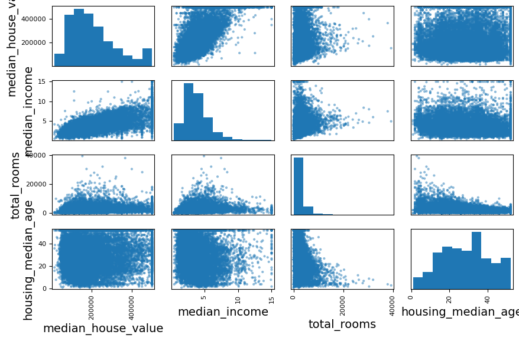

```python
from pandas.plotting import scatter_matrix

attributes = ["median_house_value", "median_income", "total_rooms",
              "housing_median_age"]
scatter_matrix(housing[attributes], figsize=(9, 6))
save_fig("scatter_matrix_plot")  # extra code
plt.show()
```

```python
# genauer hinschauen
```

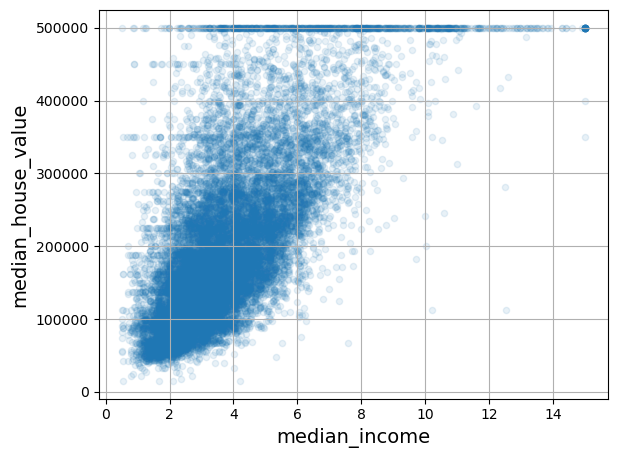

```python
housing.plot(kind="scatter", x="median_income", y="median_house_value",
             alpha=0.1, grid=True)
save_fig("income_vs_house_value_scatterplot")  # extra code
plt.show()
```

## Experimentieren mit Attribut-Kombinationen

```python
# Vielleicht gibt bessere Korrelationen, wenn man aus den Daten zusätzliche Spalten berechnet ??
```

```python
# Die Spalten "total_rooms","total_bedrooms",households" beziehen sich auf den jeweiligen Bezirk
# Die unten stehenden  Spalten sind sinnvoller
housing["rooms_per_house"] = housing["total_rooms"] / housing["households"]
housing["bedrooms_ratio"] = housing["total_bedrooms"] / housing["total_rooms"]
housing["people_per_house"] = housing["population"] / housing["households"]
```

```python
corr_matrix = housing.corr(numeric_only=True)
corrspalte=corr_matrix["median_house_value"]
corr_sortiert=corrspalte.sort_values(ascending=False)
corr_sortiert
```

```
median_house_value    1.000000
median_income         0.691021
rooms_per_house       0.146748
total_rooms           0.137587
housing_median_age    0.100654
households            0.068613
total_bedrooms        0.052117
population           -0.023027
people_per_house     -0.049029
longitude            -0.049352
latitude             -0.141098
bedrooms_ratio       -0.258419
Name: median_house_value, dtype: float64
```

# Daten vorbereiten für Algorithmen des Maschinellen Lernens

###### Wir haben uns jetzt einiges überlegt, aber wir kehren zum Originaldatensatz zurück. .......................Falls wir noch Veränderungen machen wollen, werden wir diese weiter unten automatisch einpassen.

###### Wir trennen die Zielspalte (=Target = Label) von den restlichen Daten, da wir die Zielspalte voraussagen wollen.

```python
housing_train_data = strat_train_set.drop("median_house_value", axis=1)
housing_train_labels = strat_train_set["median_house_value"].copy()
```

```python
print("Größe der Trainingsdaten", housing_train_data.shape)
print("Größe der Trainingslabels", housing_train_labels.shape)
```

```
Größe der Trainingsdaten (16512, 9)
Größe der Trainingslabels (16512,)
```

## Data Cleaning

### Schritt 1: Fehlende Werte reparieren

```python
# Wir machen uns eine Kopie des Datensatzes um die Behandlung der Null-Werte näher zu untersuchen.
housing_null = housing_train_data.copy()
```

```python
housing_null.isnull()
```

|  | longitude | latitude | housing_median_age | total_rooms | total_bedrooms | population | households | median_income | ocean_proximity |
| --- | --- | --- | --- | --- | --- | --- | --- | --- | --- |
| 16782 | False | False | False | False | False | False | False | False | False |
| 17393 | False | False | False | False | False | False | False | False | False |
| 5159 | False | False | False | False | False | False | False | False | False |
| 4839 | False | False | False | False | False | False | False | False | False |
| 2105 | False | False | False | False | False | False | False | False | False |
| ... | ... | ... | ... | ... | ... | ... | ... | ... | ... |
| 14728 | False | False | False | False | False | False | False | False | False |
| 17690 | False | False | False | False | False | False | False | False | False |
| 14843 | False | False | False | False | False | False | False | False | False |
| 16101 | False | False | False | False | False | False | False | False | False |
| 17589 | False | False | False | False | False | False | False | False | False |

16512 rows × 9 columns

```python
null_rows_idx = housing_null.isnull().any(axis=1)
null_rows_idx
```

```
16782    False
17393    False
5159     False
4839     False
2105     False
         ...
14728    False
17690    False
14843    False
16101    False
17589    False
Length: 16512, dtype: bool
```

```python
# Wir haben gesehen, dass in der bedroom-Spalte Nullwerte sind.
# Wir schauen uns die Zeilen mit den fehlenden Werten an.
null_rows_idx = housing_null.isnull().any(axis=1)
# Hierbei entsteht pandas.Series,die Booleans enthält. Sie wird aber als Index benutzt

null_rows=housing_null.loc[null_rows_idx]
print("Anzahl der Zeilen mit Nullwerten",null_rows.shape[0])
print("Inhalte der Zeilen mit Nullwerten", null_rows)
```

```
Anzahl der Zeilen mit Nullwerten 169
Inhalte der Zeilen mit Nullwerten        longitude  latitude  housing_median_age  total_rooms  total_bedrooms  \
19543    -122.44     37.73                39.0       1912.0             NaN
17796    -118.31     34.03                47.0       1315.0             NaN
9529     -118.31     33.94                40.0       1550.0             NaN
16478    -122.00     37.36                17.0       2070.0             NaN
16519    -117.86     34.01                16.0       4632.0             NaN
...          ...       ...                 ...          ...             ...
5458     -117.96     33.78                33.0       1520.0             NaN
15560    -118.26     33.83                24.0       3059.0             NaN
8379     -118.75     34.29                17.0       5512.0             NaN
2690     -122.10     37.69                41.0        746.0             NaN
8522     -117.14     33.16                16.0       1660.0             NaN

       population  households  median_income ocean_proximity
19543       970.0       406.0         4.7813        NEAR BAY
17796       785.0       245.0         1.2300       <1H OCEAN
9529        798.0       270.0         3.7750       <1H OCEAN
16478       797.0       275.0         8.6155       <1H OCEAN
16519      3038.0       727.0         5.1762       <1H OCEAN
...           ...         ...            ...             ...
5458        658.0       242.0         4.8750       <1H OCEAN
15560      2064.0       629.0         3.5518       <1H OCEAN
8379       2734.0       814.0         6.6073       <1H OCEAN
2690        387.0       161.0         3.9063        NEAR BAY
8522        733.0       214.0         5.6874       <1H OCEAN

[169 rows x 9 columns]
```

```python
# Wir haben gesehen, dass in der bedroom-Spalte Nullwerte sind.
# Wir schauen uns die Spalten mit den fehlenden Werten an.
# Wenn es mehrer Spalten wären, würden wir sie auf die folgende Weise herausfinden.
null_cols_idx = housing_null.isnull().any(axis=0)
print("Angabe, ob die Spalte Nullwerte enthält\n",null_cols_idx, sep ="")
```

```
Angabe, ob die Spalte Nullwerte enthält
longitude             False
latitude              False
housing_median_age    False
total_rooms           False
total_bedrooms         True
population            False
households            False
median_income         False
ocean_proximity       False
dtype: bool
```

```python
housing_null.loc[housing_null.isnull().any(axis=1)]
```

|  | longitude | latitude | housing_median_age | total_rooms | total_bedrooms | population | households | median_income | ocean_proximity |
| --- | --- | --- | --- | --- | --- | --- | --- | --- | --- |
| 19543 | -122.44 | 37.73 | 39.0 | 1912.0 | NaN | 970.0 | 406.0 | 4.7813 | NEAR BAY |
| 17796 | -118.31 | 34.03 | 47.0 | 1315.0 | NaN | 785.0 | 245.0 | 1.2300 | <1H OCEAN |
| 9529 | -118.31 | 33.94 | 40.0 | 1550.0 | NaN | 798.0 | 270.0 | 3.7750 | <1H OCEAN |
| 16478 | -122.00 | 37.36 | 17.0 | 2070.0 | NaN | 797.0 | 275.0 | 8.6155 | <1H OCEAN |
| 16519 | -117.86 | 34.01 | 16.0 | 4632.0 | NaN | 3038.0 | 727.0 | 5.1762 | <1H OCEAN |
| ... | ... | ... | ... | ... | ... | ... | ... | ... | ... |
| 5458 | -117.96 | 33.78 | 33.0 | 1520.0 | NaN | 658.0 | 242.0 | 4.8750 | <1H OCEAN |
| 15560 | -118.26 | 33.83 | 24.0 | 3059.0 | NaN | 2064.0 | 629.0 | 3.5518 | <1H OCEAN |
| 8379 | -118.75 | 34.29 | 17.0 | 5512.0 | NaN | 2734.0 | 814.0 | 6.6073 | <1H OCEAN |
| 2690 | -122.10 | 37.69 | 41.0 | 746.0 | NaN | 387.0 | 161.0 | 3.9063 | NEAR BAY |
| 8522 | -117.14 | 33.16 | 16.0 | 1660.0 | NaN | 733.0 | 214.0 | 5.6874 | <1H OCEAN |

169 rows × 9 columns

```python
housing_null.describe()
```

|  | longitude | latitude | housing_median_age | total_rooms | total_bedrooms | population | households | median_income |
| --- | --- | --- | --- | --- | --- | --- | --- | --- |
| count | 16512.000000 | 16512.000000 | 16512.000000 | 16512.000000 | 16343.000000 | 16512.000000 | 16512.000000 | 16512.000000 |
| mean | -119.562873 | 35.621861 | 28.632086 | 2630.738130 | 537.290277 | 1421.324612 | 499.075703 | 3.870524 |
| std | 1.999385 | 2.132813 | 12.535041 | 2165.540664 | 420.675786 | 1087.874769 | 381.399098 | 1.894218 |
| min | -124.350000 | 32.550000 | 1.000000 | 2.000000 | 1.000000 | 3.000000 | 1.000000 | 0.499900 |
| 25% | -121.790000 | 33.930000 | 18.000000 | 1448.000000 | 296.000000 | 786.000000 | 280.000000 | 2.562500 |
| 50% | -118.490000 | 34.250000 | 29.000000 | 2127.000000 | 433.000000 | 1167.500000 | 409.000000 | 3.539100 |
| 75% | -118.000000 | 37.710000 | 37.000000 | 3144.250000 | 643.000000 | 1719.000000 | 602.000000 | 4.744075 |
| max | -114.490000 | 41.950000 | 52.000000 | 39320.000000 | 6210.000000 | 16305.000000 | 5358.000000 | 15.000100 |

```python
# Wir haben 4 Optionen
# Option1: Zeile löschen
# Option2: Spalte löschen
# Option3: Ersatzwert berechnen, z.B Mittelwert,Median, Modus, constant ,z.B.42
# Option4: alle Daten auf Regelmäßigkeit untersuchen, Ersatzwert berechnen
# Wir spielen die ersten Optionen anhand einer Kopie der Daten durch.
```

```python
# Option 1
housing_ohne_NullZeilen = housing_null.dropna(subset=["total_bedrooms"])
print("Nach dem Löschen der Zeilen")
housing_ohne_NullZeilen.loc[null_rows_idx].head()
```

```
Nach dem Löschen der Zeilen
```

|  | longitude | latitude | housing_median_age | total_rooms | total_bedrooms | population | households | median_income | ocean_proximity |
| --- | --- | --- | --- | --- | --- | --- | --- | --- | --- |

```python
# Option 2
housing_ohne_NullSpalte =housing_null.drop("total_bedrooms", axis=1)
print("Nach dem Löschen der Spalte")
housing_ohne_NullSpalte.head()
```

```
Nach dem Löschen der Spalte
```

|  | longitude | latitude | housing_median_age | total_rooms | population | households | median_income | ocean_proximity |
| --- | --- | --- | --- | --- | --- | --- | --- | --- |
| 16782 | -120.60 | 35.11 | 17.0 | 2495.0 | 1292.0 | 501.0 | 2.2625 | <1H OCEAN |
| 17393 | -118.71 | 34.30 | 23.0 | 1983.0 | 978.0 | 287.0 | 6.3199 | <1H OCEAN |
| 5159 | -118.42 | 34.26 | 36.0 | 973.0 | 1086.0 | 218.0 | 3.4519 | <1H OCEAN |
| 4839 | -121.79 | 38.54 | 7.0 | 1777.0 | 4479.0 | 504.0 | 1.4653 | INLAND |
| 2105 | -117.99 | 33.79 | 33.0 | 2064.0 | 1384.0 | 315.0 | 4.5263 | <1H OCEAN |

```python
# Option 3
# Wir ersetzen den fehlenden Wert durch den Median

median_bedrooms = housing["total_bedrooms"].median()
```

```python
housing_null["total_bedrooms"] = housing_null["total_bedrooms"].fillna(median_bedrooms)  # option 3

housing_null.loc[null_rows_idx].head()
```

|  | longitude | latitude | housing_median_age | total_rooms | total_bedrooms | population | households | median_income | ocean_proximity |
| --- | --- | --- | --- | --- | --- | --- | --- | --- | --- |
| 19543 | -122.44 | 37.73 | 39.0 | 1912.0 | 433.0 | 970.0 | 406.0 | 4.7813 | NEAR BAY |
| 17796 | -118.31 | 34.03 | 47.0 | 1315.0 | 433.0 | 785.0 | 245.0 | 1.2300 | <1H OCEAN |
| 9529 | -118.31 | 33.94 | 40.0 | 1550.0 | 433.0 | 798.0 | 270.0 | 3.7750 | <1H OCEAN |
| 16478 | -122.00 | 37.36 | 17.0 | 2070.0 | 433.0 | 797.0 | 275.0 | 8.6155 | <1H OCEAN |
| 16519 | -117.86 | 34.01 | 16.0 | 4632.0 | 433.0 | 3038.0 | 727.0 | 5.1762 | <1H OCEAN |

### Fehlende Werte reparieren: es geht viel besser mit scikit-learn !

###### geeignete Arbeitsmittel bereit stellen

```python
# lückenhafte Datensätze löschen: Pandas eignet sich gut
# Lücken durch neue Werte ersetzen: Dies sollte man nicht mit pandas machen

# scikit-learn enthält mehrere Klassen, die fehlende Werte auf raffinierte Weise ersetzen können.
# Sie heißen Imputer. Ihre Anwendung folgt einem Schema.
```

```python
# Imputer arbeiten nur auf numerischen Spalten, aber nicht auf Spalten , die Strings enthalten.
# Wir machen uns eine Kopie der Numerischen Spalten, die im Trainingsdatensatz sind.
housing_num = housing_train_data[['longitude','latitude','housing_median_age','total_rooms',
                                     'total_bedrooms','population','households','median_income']]
housing_num.head()
```

|  | longitude | latitude | housing_median_age | total_rooms | total_bedrooms | population | households | median_income |
| --- | --- | --- | --- | --- | --- | --- | --- | --- |
| 16782 | -120.60 | 35.11 | 17.0 | 2495.0 | 524.0 | 1292.0 | 501.0 | 2.2625 |
| 17393 | -118.71 | 34.30 | 23.0 | 1983.0 | 280.0 | 978.0 | 287.0 | 6.3199 |
| 5159 | -118.42 | 34.26 | 36.0 | 973.0 | 221.0 | 1086.0 | 218.0 | 3.4519 |
| 4839 | -121.79 | 38.54 | 7.0 | 1777.0 | 513.0 | 4479.0 | 504.0 | 1.4653 |
| 2105 | -117.99 | 33.79 | 33.0 | 2064.0 | 324.0 | 1384.0 | 315.0 | 4.5263 |

```python
type(housing_num)
```

```
pandas.core.frame.DataFrame
```

###### Der Imputer arbeitet

```python
from sklearn.impute import SimpleImputer

imputer = SimpleImputer(strategy="median")
imputer
```

```
SimpleImputer(strategy='median')
```

```python
imputer.fit(housing_num,y=None)# Daten sind Trainingsdaten
```

```
SimpleImputer(strategy='median')
```

```python
ergebnis_imputer = imputer.transform(housing_num)# Daten sind Trainingsdaten
ergebnis_imputer
```

```
array([[-1.20600e+02,  3.51100e+01,  1.70000e+01, ...,  1.29200e+03,
         5.01000e+02,  2.26250e+00],
       [-1.18710e+02,  3.43000e+01,  2.30000e+01, ...,  9.78000e+02,
         2.87000e+02,  6.31990e+00],
       [-1.18420e+02,  3.42600e+01,  3.60000e+01, ...,  1.08600e+03,
         2.18000e+02,  3.45190e+00],
       ...,
       [-1.18550e+02,  3.43700e+01,  2.10000e+01, ...,  3.33100e+03,
         1.03800e+03,  6.77600e+00],
       [-1.18060e+02,  3.37200e+01,  1.40000e+01, ...,  9.64000e+02,
         3.19000e+02,  1.50001e+01],
       [-1.18280e+02,  3.39300e+01,  4.50000e+01, ...,  4.48000e+02,
         1.20000e+02,  3.58330e+00]])
```

```python
type(ergebnis_imputer)
```

```
numpy.ndarray
```

```python
#Alternative
imputer3 = SimpleImputer(strategy="most_frequent")
imputer3.fit(housing_num)# Daten sind Trainingsdaten
ergebnis_imputer3 = imputer3.transform(housing_num)
```

```python
# Tage später
#Testdaten herausholen
#ergebnis_test_imputer = imputer.transform(housing_testdaten)# Daten sind Trainingsdaten
```

###### Welche Informationen speichert der Imputer über sich selbst ?

```python
# Welche Strategie hat der Imputer angewandt?
imputer.strategy
```

```
'median'
```

```python
#Welche Werte hat der Imputer berechnet, während die Funktion fit ausgeführt wurde?
imputer.statistics_
```

```
array([-118.49  ,   34.25  ,   29.    , 2127.    ,  433.    , 1167.5   ,
        409.    ,    3.5391])
```

```python
# Zu welchen Spalten gehören diese Mittelwerte?
imputer.feature_names_in_
```

```
array(['longitude', 'latitude', 'housing_median_age', 'total_rooms',
       'total_bedrooms', 'population', 'households', 'median_income'],
      dtype=object)
```

```python
# Hat der Imputer wirklich alle Mediane berechnet?
# Überprüfen mit pandas, ist aber eigentlich nicht nötig
housing_num.median(axis =0)
```

```
longitude             -118.4900
latitude                34.2500
housing_median_age      29.0000
total_rooms           2127.0000
total_bedrooms         433.0000
population            1167.5000
households             409.0000
median_income            3.5391
dtype: float64
```

###### Das Ergebnis des Imputers in einen pandas.DataFrame zurückverwandeln

```python
housing_tr = pd.DataFrame(ergebnis_imputer, columns=imputer.feature_names_in_,
                          index=housing_num.index)
housing_tr.loc[null_rows_idx].head()
```

|  | longitude | latitude | housing_median_age | total_rooms | total_bedrooms | population | households | median_income |
| --- | --- | --- | --- | --- | --- | --- | --- | --- |
| 19543 | -122.44 | 37.73 | 39.0 | 1912.0 | 433.0 | 970.0 | 406.0 | 4.7813 |
| 17796 | -118.31 | 34.03 | 47.0 | 1315.0 | 433.0 | 785.0 | 245.0 | 1.2300 |
| 9529 | -118.31 | 33.94 | 40.0 | 1550.0 | 433.0 | 798.0 | 270.0 | 3.7750 |
| 16478 | -122.00 | 37.36 | 17.0 | 2070.0 | 433.0 | 797.0 | 275.0 | 8.6155 |
| 16519 | -117.86 | 34.01 | 16.0 | 4632.0 | 433.0 | 3038.0 | 727.0 | 5.1762 |

## Schritt 3: Text durch Zahlen ersetzen

Das folgende gilt nicht nur für Spalten mit Text, sondern auch für alle anderen Spalten mit kategorialen Dateninhalten

### Text durch Zahlen ersetzen. Die Zahlen werden einer Skala (Treppe) entnommen.

###### geeignete Arbeitsmittel bereit stellen

```python
# Wir isolieren die Spalte, die den Text enthält
housing_cat = housing_train_data[["ocean_proximity"]]
housing_cat.head(12)
```

|  | ocean_proximity |
| --- | --- |
| 16782 | <1H OCEAN |
| 17393 | <1H OCEAN |
| 5159 | <1H OCEAN |
| 4839 | INLAND |
| 2105 | <1H OCEAN |
| 19172 | INLAND |
| 15434 | NEAR OCEAN |
| 6891 | INLAND |
| 5005 | <1H OCEAN |
| 12090 | NEAR BAY |
| 8849 | <1H OCEAN |
| 4288 | INLAND |

###### der Encoder arbeitet

```python
from sklearn.preprocessing import OrdinalEncoder

ordinal_encoder = OrdinalEncoder()
ordinal_encoder.fit(housing_cat)
ergebnis_encoder = ordinal_encoder.transform(housing_cat)
```

###### Ergebnisse der Arbeit ansehen

```python
# Die umgeformte Menge
ergebnis_encoder[6:12]
```

```
array([[4.],
       [1.],
       [0.],
       [3.],
       [0.],
       [1.]])
```

```python
# Die umgeformte Menge
ergebnis_encoder[:6]
```

```
array([[0.],
       [0.],
       [0.],
       [1.],
       [0.],
       [1.]])
```

```python
#Welche Werte hat der Imputer berechnet, während die Funktion fit ausgeführt wurde?
ordinal_encoder.categories_
```

```
[array(['<1H OCEAN', 'INLAND', 'ISLAND', 'NEAR BAY', 'NEAR OCEAN'],
       dtype=object)]
```

### Alternative :Text durch One-Hot-Spalten ersetzen

###### der Encoder arbeitet

```python
from sklearn.preprocessing import OneHotEncoder

cat_encoder = OneHotEncoder()
cat_encoder.fit(housing_cat)
ergebnis_1hot = cat_encoder.transform(housing_cat)
```

###### Ergebnisse der Arbeit ansehen

```python
ergebnis_1hot
#dense matrix : normal
# sparse matrix: enthält überwiegend 0
```

```
<16512x5 sparse matrix of type '<class 'numpy.float64'>'
	with 16512 stored elements in Compressed Sparse Row format>
```

By default, the `OneHotEncoder` class returns a sparse array, but we can convert it to a dense array if needed by calling the `toarray()` method:

```python
#Wenn wir das Ergebnis ansehen wollen,
#müssen wir es aus der komprimierten Form in einen normalen array zurückverwandeln.
print("Originaldaten\n",housing_cat[:8])
print("umgeformte daten\n",ergebnis_1hot.toarray()[:8])
```

```
Originaldaten
       ocean_proximity
16782       <1H OCEAN
17393       <1H OCEAN
5159        <1H OCEAN
4839           INLAND
2105        <1H OCEAN
19172          INLAND
15434      NEAR OCEAN
6891           INLAND
umgeformte daten
 [[1. 0. 0. 0. 0.]
 [1. 0. 0. 0. 0.]
 [1. 0. 0. 0. 0.]
 [0. 1. 0. 0. 0.]
 [1. 0. 0. 0. 0.]
 [0. 1. 0. 0. 0.]
 [0. 0. 0. 0. 1.]
 [0. 1. 0. 0. 0.]]
```

```python
# Wenn man den OneHotEncoder gleich ohne Kompression ansetzt, braucht man
# den Parameter "sparse" oder "sparse_output".
# Der Parameter hängt von der installierten Version ab.
cat_encoder = OneHotEncoder(sparse_output=False)
housing_cat_1hot = cat_encoder.fit_transform(housing_cat)
housing_cat_1hot
```

```
array([[1., 0., 0., 0., 0.],
       [1., 0., 0., 0., 0.],
       [1., 0., 0., 0., 0.],
       ...,
       [1., 0., 0., 0., 0.],
       [0., 0., 0., 0., 1.],
       [1., 0., 0., 0., 0.]])
```

```python
# Wie hat der Encoder den Aufbau der Spalten organisiert?
cat_encoder.categories_
```

```
[array(['<1H OCEAN', 'INLAND', 'ISLAND', 'NEAR BAY', 'NEAR OCEAN'],
       dtype=object)]
```

## Schritt 4: Skalieren

```python
#print(np.get_printoptions())
np.set_printoptions(threshold=10,precision =4)
```

###### der MinMaxScaler arbeitet

```python
from sklearn.preprocessing import MinMaxScaler

min_max_scaler = MinMaxScaler()
#min_max_scaler = MinMaxScaler(feature_range=(-1, 1))

min_max_scaler.fit(housing_num)
housing_num_min_max_scaled = min_max_scaler.transform(housing_num)
ergebnis_scaler = min_max_scaler.transform(housing_num)

print("Original\n",housing_num[:8])
print("skaliert\n",housing_num_min_max_scaled[:8])
```

```
Original
        longitude  latitude  housing_median_age  total_rooms  total_bedrooms  \
16782    -120.60     35.11                17.0       2495.0           524.0
17393    -118.71     34.30                23.0       1983.0           280.0
5159     -118.42     34.26                36.0        973.0           221.0
4839     -121.79     38.54                 7.0       1777.0           513.0
2105     -117.99     33.79                33.0       2064.0           324.0
19172    -121.09     37.33                40.0        524.0           112.0
15434    -121.99     36.97                15.0       3044.0           786.0
6891     -119.06     36.15                20.0       1282.0           273.0

       population  households  median_income
16782      1292.0       501.0         2.2625
17393       978.0       287.0         6.3199
5159       1086.0       218.0         3.4519
4839       4479.0       504.0         1.4653
2105       1384.0       315.0         4.5263
19172       329.0        96.0         1.7188
15434      1306.0       693.0         2.1771
6891        852.0       247.0         1.6354
skaliert
 [[0.3803 0.2723 0.3137 ... 0.0791 0.0933 0.1216]
 [0.572  0.1862 0.4314 ... 0.0598 0.0534 0.4014]
 [0.6014 0.1819 0.6863 ... 0.0664 0.0405 0.2036]
 ...
 [0.3306 0.5085 0.7647 ... 0.02   0.0177 0.0841]
 [0.2394 0.4702 0.2745 ... 0.0799 0.1292 0.1157]
 [0.5365 0.383  0.3725 ... 0.0521 0.0459 0.0783]]
```

###### alternativ: der StandardScaler arbeitet

```python
from sklearn.preprocessing import StandardScaler

std_scaler = StandardScaler()
housing_num_std_scaled = std_scaler.fit_transform(housing_num)
ergebnis_std_scaler    = std_scaler.fit_transform(housing_num)

print("Original\n",housing_num[:8])
print("skaliert\n",housing_num_std_scaled[:8])
```

```
Original
        longitude  latitude  housing_median_age  total_rooms  total_bedrooms  \
16782    -120.60     35.11                17.0       2495.0           524.0
17393    -118.71     34.30                23.0       1983.0           280.0
5159     -118.42     34.26                36.0        973.0           221.0
4839     -121.79     38.54                 7.0       1777.0           513.0
2105     -117.99     33.79                33.0       2064.0           324.0
19172    -121.09     37.33                40.0        524.0           112.0
15434    -121.99     36.97                15.0       3044.0           786.0
6891     -119.06     36.15                20.0       1282.0           273.0

       population  households  median_income
16782      1292.0       501.0         2.2625
17393       978.0       287.0         6.3199
5159       1086.0       218.0         3.4519
4839       4479.0       504.0         1.4653
2105       1384.0       315.0         4.5263
19172       329.0        96.0         1.7188
15434      1306.0       693.0         2.1771
6891        852.0       247.0         1.6354
skaliert
 [[-0.5187 -0.24   -0.928  ... -0.1189  0.005  -0.8489]
 [ 0.4266 -0.6198 -0.4493 ... -0.4075 -0.5561  1.2931]
 [ 0.5716 -0.6385  0.5878 ... -0.3082 -0.737  -0.221 ]
 ...
 [-0.7638  0.8009  0.9069 ... -1.0041 -1.0569 -1.136 ]
 [-1.214   0.6321 -1.0876 ... -0.106   0.5085 -0.894 ]
 [ 0.2515  0.2476 -0.6887 ... -0.5234 -0.6609 -1.18  ]]
```

## Schritt 5: Angepasste Transformer einsetzen

#### Hier wird gezeigt, wie man Transformer selbst schreiben kann

###### Beispiel 1. Eine Spalte mit Hilfe de Logarithmusfunktion umformen

```python
from sklearn.preprocessing import FunctionTransformer

log_transformer = FunctionTransformer(func =np.log, inverse_func=np.exp)
population_logarithmisch = log_transformer.transform(housing[["population"]])
anzeige = pd.concat((housing[["population"]],population_logarithmisch),axis=1, keys=["Original","Logarithmisch umgeformt"])
print(anzeige)
```

```
        Original Logarithmisch umgeformt
      population              population
16782     1292.0                7.163947
17393      978.0                6.885510
5159      1086.0                6.990257
4839      4479.0                8.407155
2105      1384.0                7.232733
...          ...                     ...
14728     1156.0                7.052721
17690     1468.0                7.291656
14843     3331.0                8.111028
16101      964.0                6.871091
17589      448.0                6.104793

[16512 rows x 2 columns]
```

###### Beispiel 2. Mit den Datenwerten aus 2 Spalten eine neue Spalte berechnen

Hiermit können solche Funktionen, wie Bewohner pro Haushalt berechnet werden

```python
verhältnis_transformer = FunctionTransformer(lambda X: X.iloc[:, 0]/X.iloc[:,1])

population_geteilt = verhältnis_transformer.transform(housing_num[["population", "households"]])
anzeige = pd.concat((housing[["population", "households"]],population_geteilt),
                    axis=1, keys=["Original","transformiert"])
anzeige
```

|  | Original population | Original households | transformiert 0 |
| --- | --- | --- | --- |
| 16782 | 1292.0 | 501.0 | 2.578842 |
| 17393 | 978.0 | 287.0 | 3.407666 |
| 5159 | 1086.0 | 218.0 | 4.981651 |
| 4839 | 4479.0 | 504.0 | 8.886905 |
| 2105 | 1384.0 | 315.0 | 4.393651 |
| ... | ... | ... | ... |
| 14728 | 1156.0 | 380.0 | 3.042105 |
| 17690 | 1468.0 | 339.0 | 4.330383 |
| 14843 | 3331.0 | 1038.0 | 3.209056 |
| 16101 | 964.0 | 319.0 | 3.021944 |
| 17589 | 448.0 | 120.0 | 3.733333 |

16512 rows × 3 columns

###### 3. eine eigene Transformerklasse schreiben

Hier zeigt das Beispiel wie ein Scaler intern funktioniert

```python
from sklearn.base import BaseEstimator, TransformerMixin
from sklearn.utils.validation import check_array, check_is_fitted

class StandardScalerClone(BaseEstimator, TransformerMixin):
    def __init__(self, with_mean=True):
        self.with_mean = with_mean

    def fit(self, X, y=None):  # y is required even though we don't use it
        X = check_array(X)  # checks that X is an array with finite float values
        if self.with_mean:
            self.mean_ = X.mean(axis=0)
        else:
            self.mean_=0
        self.scale_ = X.std(axis=0)
        self.n_features_in_ = X.shape[1]  # every estimator stores this in fit()
        return self  # always return self!

    def transform(self, X):
        check_is_fitted(self)  # looks for learned attributes (with trailing _)
        X = check_array(X)
        assert self.n_features_in_ == X.shape[1]
        if self.with_mean:
            X = X - self.mean_
        return X / self.scale_
```

```python
arbeiter = StandardScalerClone(with_mean=False)
arbeiter.fit(X=ergebnis_imputer)
X_ohneLücken_skaliert = arbeiter.transform(X=ergebnis_imputer)
arbeiter.fit_transform(X=ergebnis_imputer)
arbeiter.get_params()
```

```
{'with_mean': False}
```

Hier schreiben wir eine Klasse, die Spalten hinzufügt, die sich aus den bisherigen Spalten berechnen lassen

```python
from sklearn.base import BaseEstimator, TransformerMixin

# get the right column indices: safer than hard-coding indices 3, 4, 5, 6


class AttributesAdder(BaseEstimator, TransformerMixin):
    def __init__(self, nummern_paare, neue_spaltennamen):
        #spalten_paare ist eine Liste, die Paare von Spaltennummern enthält
        # Die Spalte mit der ersten Nummer wird später durch die Spalte mit der zweiten Nummer geteilt
        #Die erste Spalte in Zählerliste wird später geteilt durch die erste Nennung in Nennerliste
        # Dasselbe für alle weiteren Einträge
        self.nummern_paare = nummern_paare
        self.neue_spaltennamen = neue_spaltennamen


    def fit(self, X, y=None):
        return self  # sonst passiert nichts

    def erzeuge_eine_neue_spalte(self,X,paar):
        #suche anhand der Zahlen die entsprechenden Spalten aus dem Datensatz X
        zähler_nr = paar[0]
        #print(X.shape)
        nenner_nr = paar[1]
        # teile die erste Spalte durch die zweite Spalte,um Verhältniszahlen zu bekommen
        neue_spalte = X[:,zähler_nr] / X[:,nenner_nr]
        return neue_spalte

    def transform(self, X, y=None):
        # Wir gehen davon aus, dass X kein DataFrame ist, sondern bereits ein numpy-Array
        X_neu = X
        for paar in self.nummern_paare:
            neue_spalte =self.erzeuge_eine_neue_spalte(X,paar)# erzeuge Spalte
            X_neu = np.c_[X_neu, neue_spalte]#hänge spalte an die bisherigen Einträge von X an

        return X_neu

# Damit wir ganz sicher sind, lassen wir uns die Spaltennummer aus dem DataFrame berechnen
rooms_ix, bedrooms_ix, population_ix, household_ix = [
    list(housing.columns).index(col)
    for col in ("total_rooms", "total_bedrooms", "population", "households")]
print('Die Spaltennummern von "total_rooms", "total_bedrooms", "population", "households":',
        rooms_ix,bedrooms_ix,population_ix, household_ix)


# Die Instanz wird erzeugt
nummern_paare = [(bedrooms_ix,rooms_ix ),(population_ix,household_ix ),(rooms_ix,household_ix )]
liste_neue_spaltennamen = [ "bedroom_ratio","persons_per_house","rooms_per_house"]

#########################################################################
# Die Klasse wird getestet
print("Das gewählte Spaltenpaar",nummern_paare[2])
attr_adder = AttributesAdder(nummern_paare = nummern_paare,
                            neue_spaltennamen = liste_neue_spaltennamen )
# Die Instanz soll arbeiten

ergebnis_AttributesAdder = attr_adder.fit_transform(housing_num.to_numpy())
#print(ergebnis_AttributesAdder.shape)
# Zurückverwandlung des Transformationsergebnisses in einen DataFrame
columns_erweitert = list(housing_num)
columns_erweitert.extend(liste_neue_spaltennamen)
print(columns_erweitert)

df = pd.DataFrame(ergebnis_AttributesAdder,columns = columns_erweitert)
print("\nDataframe mit zusätzlicher Spalte")
df
```

```
Die Spaltennummern von "total_rooms", "total_bedrooms", "population", "households": 3 4 5 6
Das gewählte Spaltenpaar (3, 6)
['longitude', 'latitude', 'housing_median_age', 'total_rooms', 'total_bedrooms', 'population', 'households', 'median_income', 'bedroom_ratio', 'persons_per_house', 'rooms_per_house']

Dataframe mit zusätzlicher Spalte
```

|  | longitude | latitude | housing_median_age | total_rooms | total_bedrooms | population | households | median_income | bedroom_ratio | persons_per_house | rooms_per_house |
| --- | --- | --- | --- | --- | --- | --- | --- | --- | --- | --- | --- |
| 0 | -120.60 | 35.11 | 17.0 | 2495.0 | 524.0 | 1292.0 | 501.0 | 2.2625 | 0.210020 | 2.578842 | 4.980040 |
| 1 | -118.71 | 34.30 | 23.0 | 1983.0 | 280.0 | 978.0 | 287.0 | 6.3199 | 0.141200 | 3.407666 | 6.909408 |
| 2 | -118.42 | 34.26 | 36.0 | 973.0 | 221.0 | 1086.0 | 218.0 | 3.4519 | 0.227133 | 4.981651 | 4.463303 |
| 3 | -121.79 | 38.54 | 7.0 | 1777.0 | 513.0 | 4479.0 | 504.0 | 1.4653 | 0.288689 | 8.886905 | 3.525794 |
| 4 | -117.99 | 33.79 | 33.0 | 2064.0 | 324.0 | 1384.0 | 315.0 | 4.5263 | 0.156977 | 4.393651 | 6.552381 |
| ... | ... | ... | ... | ... | ... | ... | ... | ... | ... | ... | ... |
| 16507 | -118.31 | 33.97 | 47.0 | 2066.0 | 422.0 | 1156.0 | 380.0 | 2.7917 | 0.204259 | 3.042105 | 5.436842 |
| 16508 | -121.44 | 36.51 | 31.0 | 1636.0 | 380.0 | 1468.0 | 339.0 | 3.2219 | 0.232274 | 4.330383 | 4.825959 |
| 16509 | -118.55 | 34.37 | 21.0 | 7010.0 | 1063.0 | 3331.0 | 1038.0 | 6.7760 | 0.151641 | 3.209056 | 6.753372 |
| 16510 | -118.06 | 33.72 | 14.0 | 2665.0 | 331.0 | 964.0 | 319.0 | 15.0001 | 0.124203 | 3.021944 | 8.354232 |
| 16511 | -118.28 | 33.93 | 45.0 | 529.0 | 112.0 | 448.0 | 120.0 | 3.5833 | 0.211720 | 3.733333 | 4.408333 |

16512 rows × 11 columns

## Alle Schritte in einem Rutsch: Pipelines

Wir bauen eine Pipeline, die nacheinander alle Vorbereitungsschritte ausführt.

###### Die Pipeline arbeitet

```python
from sklearn.pipeline import Pipeline
from sklearn.decomposition import PCA
#print("Argumente für den AttributesAdder",liste_neue_spaltennamen,end="\n\n")
num_pipeline = Pipeline([
    ("impute", SimpleImputer(strategy="median")),
    ("spaltenergänzung", AttributesAdder(nummern_paare,liste_neue_spaltennamen )),

    ("pca",PCA()),
    ("standardize", StandardScaler())

])
num_pipeline
```

```
Pipeline(steps=[('impute', SimpleImputer(strategy='median')),
                ('spaltenergänzung',
                 AttributesAdder(neue_spaltennamen=['bedroom_ratio',
                                                    'persons_per_house',
                                                    'rooms_per_house'],
                                 nummern_paare=[(4, 3), (5, 6), (3, 6)])),
                ('pca', PCA()), ('standardize', StandardScaler())])
```

```python
# Achtung: Hier müssen im Moment die Kommentare gesetzt bleiben, sonst gibt es weiter unten Chaos
# Alternative zur Zelle oben
#from sklearn.pipeline import make_pipeline

#num_pipeline = make_pipeline(SimpleImputer(strategy="median"), StandardScaler())
```

```python
housing_num_prepared = num_pipeline.fit_transform(housing_num)
df_housing_num_prepared = pd.DataFrame(housing_num_prepared,
                                       columns=columns_erweitert)
```

###### Anzeige des Ergebnisses

```python
housing_num_prepared[:6].round(2)
#print("Zeilen und Spalten von housing_prepared",housing_num_prepared.shape)
print("Anzahl der Originalspalten",housing_num.shape[1])
print("Anzahl derSpalten nach der Transformation",housing_num_prepared.shape[1])
```

```
Anzahl der Originalspalten 8
Anzahl derSpalten nach der Transformation 11
```

```python
df_housing_num_prepared.head(6)
```

|  | longitude | latitude | housing_median_age | total_rooms | total_bedrooms | population | households | median_income | bedroom_ratio | persons_per_house | rooms_per_house |
| --- | --- | --- | --- | --- | --- | --- | --- | --- | --- | --- | --- |
| 0 | -0.071885 | -0.110382 | 0.223942 | 0.252064 | -1.050945 | -0.000970 | 0.149614 | -0.387167 | 0.845776 | 2.916393 | -0.609232 |
| 1 | -0.340545 | -0.300636 | -0.794596 | 0.216172 | -0.556426 | 0.031392 | -0.613481 | 0.595664 | -0.873149 | 0.339355 | -0.542652 |
| 2 | -0.698686 | 0.755415 | -0.597033 | -0.349525 | 0.384452 | 0.101776 | -0.554083 | -0.216540 | -0.034619 | 0.075017 | -0.052189 |
| 3 | 0.201108 | 6.159706 | -3.163949 | -2.779007 | -1.753818 | -0.734347 | 2.520043 | -0.104015 | -0.769258 | -0.335613 | 0.058921 |
| 4 | -0.238203 | 0.359158 | -1.070153 | -0.252105 | 0.352250 | 0.001714 | -0.777633 | 0.444805 | 0.019948 | 0.184091 | -0.772847 |
| 5 | -1.004174 | -0.233083 | -0.199330 | -0.160572 | 0.637368 | 0.060911 | 0.754908 | -0.331992 | 1.161567 | 0.349873 | -0.356163 |

###### Die Eigenschaften der Pipeline

```python
# Die Stufen der Pipeline. Von hier aus können wir einzelne Stufen ansprechen.
num_pipeline.steps
```

```
[('impute', SimpleImputer(strategy='median')),
 ('spaltenergänzung',
  AttributesAdder(neue_spaltennamen=['bedroom_ratio', 'persons_per_house',
                                     'rooms_per_house'],
                  nummern_paare=[(4, 3), (5, 6), (3, 6)])),
 ('pca', PCA()),
 ('standardize', StandardScaler())]
```

```python
#Die erste Stufe der Pipeline
print(num_pipeline[0])
```

```
SimpleImputer(strategy='median')
```

```python
#Die zweite Stufe der Pipeline
print(num_pipeline[1])
```

```
AttributesAdder(neue_spaltennamen=['bedroom_ratio', 'persons_per_house',
                                   'rooms_per_house'],
                nummern_paare=[(4, 3), (5, 6), (3, 6)])
```

```python
# Das bunch ( eine Art dictionary), das die einzelnen Stufen angibt
print("named steps\n",num_pipeline.named_steps)#["simpleimputer"]
print()
print("Zugriffsmöglichkeiten auf die named steps:\n",num_pipeline.named_steps.keys())
print()
#print("Inhalt der ersten Stufe:",num_pipeline.named_steps["fritz"])
# der Fehler ist gewollt, hier muss natürlich der oben definierte Name stehen
print("Inhalt der ersten Stufe:\n",num_pipeline.named_steps["impute"])
#print("Inhalt der ersten Stufe, alternative Formulierung:",num_pipeline[0])
```

```
named steps
 {'impute': SimpleImputer(strategy='median'), 'spaltenergänzung': AttributesAdder(neue_spaltennamen=['bedroom_ratio', 'persons_per_house',
                                   'rooms_per_house'],
                nummern_paare=[(4, 3), (5, 6), (3, 6)]), 'pca': PCA(), 'standardize': StandardScaler()}

Zugriffsmöglichkeiten auf die named steps:
 dict_keys(['impute', 'spaltenergänzung', 'pca', 'standardize'])

Inhalt der ersten Stufe:
 SimpleImputer(strategy='median')
```

```python
num_pipeline.get_params()
```

```
{'memory': None,
 'steps': [('impute', SimpleImputer(strategy='median')),
  ('spaltenergänzung',
   AttributesAdder(neue_spaltennamen=['bedroom_ratio', 'persons_per_house',
                                      'rooms_per_house'],
                   nummern_paare=[(4, 3), (5, 6), (3, 6)])),
  ('pca', PCA()),
  ('standardize', StandardScaler())],
 'verbose': False,
 'impute': SimpleImputer(strategy='median'),
 'spaltenergänzung': AttributesAdder(neue_spaltennamen=['bedroom_ratio', 'persons_per_house',
                                    'rooms_per_house'],
                 nummern_paare=[(4, 3), (5, 6), (3, 6)]),
 'pca': PCA(),
 'standardize': StandardScaler(),
 'impute__add_indicator': False,
 'impute__copy': True,
 'impute__fill_value': None,
 'impute__keep_empty_features': False,
 'impute__missing_values': nan,
 'impute__strategy': 'median',
 'impute__verbose': 'deprecated',
 'spaltenergänzung__neue_spaltennamen': ['bedroom_ratio',
  'persons_per_house',
  'rooms_per_house'],
 'spaltenergänzung__nummern_paare': [(4, 3), (5, 6), (3, 6)],
 'pca__copy': True,
 'pca__iterated_power': 'auto',
 'pca__n_components': None,
 'pca__n_oversamples': 10,
 'pca__power_iteration_normalizer': 'auto',
 'pca__random_state': None,
 'pca__svd_solver': 'auto',
 'pca__tol': 0.0,
 'pca__whiten': False,
 'standardize__copy': True,
 'standardize__with_mean': True,
 'standardize__with_std': True}
```

```python
# Die Inhalte der Stufen können verändert werden.
# Dazu müssen die Parameter der Transformer neu gesetzt werden
num_pipeline.set_params(impute__strategy="mean")
```

```
Pipeline(steps=[('impute', SimpleImputer()),
                ('spaltenergänzung',
                 AttributesAdder(neue_spaltennamen=['bedroom_ratio',
                                                    'persons_per_house',
                                                    'rooms_per_house'],
                                 nummern_paare=[(4, 3), (5, 6), (3, 6)])),
                ('pca', PCA()), ('standardize', StandardScaler())])
```

```python
# Mit einem ColumnTransformer werden die verschiedenen Umformungen zusammengeführt
from sklearn.compose import ColumnTransformer
from sklearn.preprocessing import OneHotEncoder
from sklearn.pipeline import make_pipeline

num_attribs = ["longitude", "latitude", "housing_median_age", "total_rooms",
               "total_bedrooms", "population", "households", "median_income"]
cat_attribs = ["ocean_proximity"]

cat_pipeline = make_pipeline(
    SimpleImputer(strategy="most_frequent"),
    OneHotEncoder(handle_unknown="ignore"))

preparation = ColumnTransformer([
    ("num", num_pipeline, num_attribs),
    ("cat", cat_pipeline, cat_attribs),
])
preparation
```

```
ColumnTransformer(transformers=[('num',
                                 Pipeline(steps=[('impute', SimpleImputer()),
                                                 ('spaltenergänzung',
                                                  AttributesAdder(neue_spaltennamen=['bedroom_ratio',
                                                                                     'persons_per_house',
                                                                                     'rooms_per_house'],
                                                                  nummern_paare=[(4,
                                                                                  3),
                                                                                 (5,
                                                                                  6),
                                                                                 (3,
                                                                                  6)])),
                                                 ('pca', PCA()),
                                                 ('standardize',
                                                  StandardScaler())]),
                                 ['longitude', 'latitude', 'housing_median_age',
                                  'total_rooms', 'total_bedrooms', 'population',
                                  'households', 'median_income']),
                                ('cat',
                                 Pipeline(steps=[('simpleimputer',
                                                  SimpleImputer(strategy='most_frequent')),
                                                 ('onehotencoder',
                                                  OneHotEncoder(handle_unknown='ignore'))]),
                                 ['ocean_proximity'])])
```

```python
# alternative Formulierung:
# der ColumnTransformer führt den speziellen Pipelines die Spalten zu, die sie umformen sollen.
# Er fasst dann das Ergebnis zusammen.
from sklearn.compose import make_column_selector, make_column_transformer

preparation2 = make_column_transformer(
    (num_pipeline, make_column_selector(dtype_include=np.number)),
    (cat_pipeline, make_column_selector(dtype_include=object)),
)
preparation2
```

```
ColumnTransformer(transformers=[('pipeline-1',
                                 Pipeline(steps=[('impute', SimpleImputer()),
                                                 ('spaltenergänzung',
                                                  AttributesAdder(neue_spaltennamen=['bedroom_ratio',
                                                                                     'persons_per_house',
                                                                                     'rooms_per_house'],
                                                                  nummern_paare=[(4,
                                                                                  3),
                                                                                 (5,
                                                                                  6),
                                                                                 (3,
                                                                                  6)])),
                                                 ('pca', PCA()),
                                                 ('standardize',
                                                  StandardScaler())]),
                                 <sklearn.compose._column_transformer.make_column_selector object at 0x000001F57FFC04F0>),
                                ('pipeline-2',
                                 Pipeline(steps=[('simpleimputer',
                                                  SimpleImputer(strategy='most_frequent')),
                                                 ('onehotencoder',
                                                  OneHotEncoder(handle_unknown='ignore'))]),
                                 <sklearn.compose._column_transformer.make_column_selector object at 0x000001F57FFC0070>)])
```

```python
housing_train_prepared = preparation.fit_transform(housing_train_data)
housing_train_prepared[:6]
#housing_train_prepared.shape
```

```
array([[-0.072 , -0.1105,  0.2196, ...,  0.    ,  0.    ,  0.    ],
       [-0.3406, -0.3008, -0.7997, ...,  0.    ,  0.    ,  0.    ],
       [-0.6988,  0.7552, -0.6032, ...,  0.    ,  0.    ,  0.    ],
       [ 0.201 ,  6.1592, -3.1776, ...,  0.    ,  0.    ,  0.    ],
       [-0.2383,  0.3589, -1.0763, ...,  0.    ,  0.    ,  0.    ],
       [-1.0042, -0.2332, -0.2043, ...,  0.    ,  0.    ,  0.    ]])
```

```python
import pickle

with open('datasets/pipeline.pickle', 'wb') as f:
    # Einpacken der Pipeline
    pickle.dump(preparation, f, pickle.HIGHEST_PROTOCOL)
```

```python
#Dateiname sollte housing_train_prepared.pickle heißen
# vor dem Einpacken der Testmenge darf die preparation kein fit machen !!!

import pickle
with open('datasets/housing_train_prepared.pickle', 'wb') as f:
    # Einpacken von allen vorbereiteten Trainingsdaten
    pickle.dump(housing_train_prepared, f, pickle.HIGHEST_PROTOCOL)

with open('datasets/housing_train_labels.pickle', 'wb') as f:
    #Einpacken der Trainingslabel
    pickle.dump(housing_train_labels, f, pickle.HIGHEST_PROTOCOL)




housing_test_prepared = preparation.transform(strat_test_set[strat_train_set.keys()])
housing_test_labels =strat_test_set["median_house_value"]

with open('datasets/housing_test_prepared.pickle', 'wb') as f:
    # Einpacken von allen unvorbereiteten Testdaten
    pickle.dump(housing_test_prepared, f, pickle.HIGHEST_PROTOCOL)
with open('datasets/housing_test_labels.pickle', 'wb') as f:
    # Einpacken von allen unvorbereiteten Testdaten
    pickle.dump(housing_test_labels, f, pickle.HIGHEST_PROTOCOL)
```

# Was man zusätzlich tun könnte:

bestimmte Zeilen entfernen, die den Voraussage-Algorithmus auf falsche Wege führen könnten.

### Ausreißer entfernen (Beispiel)

```python
# Hier gibt es mehrere möglichkeiten.
# Ideallerweise benutzt man Machine-Learning-Klassen, die mit nicht-überwachtem lernen  die Ausreißer herausfinden.
# Dies ist oft besser als die Methoden, die in Statistik und Data-Analytics benutzt werden.
# Manchmal werden aber zu viele Daten als Ausreißer angesprochen.
# Aber Achtung: das Entfernen von Ausreißern muss fachlich gerechtfertigt sein.
#    Man muss auf jedenfall kontrollieren, ob es plausibel ist, diese Datensätze zu entfernen.

from sklearn.ensemble import IsolationForest
# IsolationForest zeigt unüberwachtes Lernen.
# In der sogenannten "Prediction" des IsolationForest werden die Labels für jeden Datensatz neu erzeugt.
# Sie sind vorher nicht vorhanden
# Für jeden Datensatz wird eine 1 zurückgegeben, wenn er "normal" ist.
# Eine -1 wird zurückgegeben, wenn der Datensatz als "Outlier" eingestuft wird.

isolation_forest = IsolationForest(random_state=42)
outlier_pred = isolation_forest.fit_predict(housing_train_prepared )
print(outlier_pred[:10])
```

```
[ 1  1  1 -1  1  1  1  1  1  1]
```

```python
ausreißer = housing_tr.iloc[outlier_pred == -1]
ausreißer.head()
```

|  | longitude | latitude | housing_median_age | total_rooms | total_bedrooms | population | households | median_income |
| --- | --- | --- | --- | --- | --- | --- | --- | --- |
| 4839 | -121.79 | 38.54 | 7.0 | 1777.0 | 513.0 | 4479.0 | 504.0 | 1.4653 |
| 7468 | -118.86 | 34.07 | 16.0 | 1409.0 | 244.0 | 970.0 | 172.0 | 8.0144 |
| 18266 | -121.97 | 37.31 | 21.0 | 7628.0 | 2166.0 | 3637.0 | 1749.0 | 3.6401 |
| 15912 | -122.44 | 37.79 | 52.0 | 3785.0 | 808.0 | 1371.0 | 799.0 | 6.4209 |
| 16337 | -118.26 | 33.82 | 28.0 | 5091.0 | 1074.0 | 4753.0 | 1033.0 | 3.6477 |

```python
housing_tr_ohne_Ausreißer = housing_tr.iloc[outlier_pred == 1]
print("Aus den ersten 20 Datensätzen wurden die Ausreißer entfernt\n",housing_tr_ohne_Ausreißer[:20] )
housing_train_labels_ohne_Ausreißer = housing_train_labels.iloc[outlier_pred == 1]
print("Die Labels, die den normalen Datensätzen entsprechen",housing_train_labels_ohne_Ausreißer)
# danach housing_tr_ohne_Ausreißer mit pickle einpacken und später zum Training verwenden.
```

```
Aus den ersten 20 Datensätzen wurden die Ausreißer entfernt
        longitude  latitude  housing_median_age  total_rooms  total_bedrooms  \
16782    -120.60     35.11                17.0       2495.0           524.0
17393    -118.71     34.30                23.0       1983.0           280.0
5159     -118.42     34.26                36.0        973.0           221.0
2105     -117.99     33.79                33.0       2064.0           324.0
19172    -121.09     37.33                40.0        524.0           112.0
15434    -121.99     36.97                15.0       3044.0           786.0
6891     -119.06     36.15                20.0       1282.0           273.0
5005     -117.00     32.80                33.0       1816.0           325.0
12090    -122.46     37.73                52.0       2401.0           346.0
8849     -117.00     32.73                17.0       6050.0          1143.0
4288     -119.98     38.92                28.0       1408.0           312.0
1450     -118.44     34.50                 5.0       1514.0           220.0
7942     -117.91     33.85                22.0       1178.0           289.0
```

[output cut: 41 more lines]

```python
housing.describe()
```

|  | longitude | latitude | housing_median_age | total_rooms | total_bedrooms | population | households | median_income | median_house_value | rooms_per_house | bedrooms_ratio | people_per_house |
| --- | --- | --- | --- | --- | --- | --- | --- | --- | --- | --- | --- | --- |
| count | 16512.000000 | 16512.000000 | 16512.000000 | 16512.000000 | 16343.000000 | 16512.000000 | 16512.000000 | 16512.000000 | 16512.000000 | 16512.000000 | 16343.000000 | 16512.000000 |
| mean | -119.562873 | 35.621861 | 28.632086 | 2630.738130 | 537.290277 | 1421.324612 | 499.075703 | 3.870524 | 206827.952943 | 5.431670 | 0.212853 | 3.001739 |
| std | 1.999385 | 2.132813 | 12.535041 | 2165.540664 | 420.675786 | 1087.874769 | 381.399098 | 1.894218 | 115522.475502 | 2.577536 | 0.057377 | 5.136527 |
| min | -124.350000 | 32.550000 | 1.000000 | 2.000000 | 1.000000 | 3.000000 | 1.000000 | 0.499900 | 14999.000000 | 1.000000 | 0.100000 | 0.692308 |
| 25% | -121.790000 | 33.930000 | 18.000000 | 1448.000000 | 296.000000 | 786.000000 | 280.000000 | 2.562500 | 119100.000000 | 4.442406 | 0.175665 | 2.430456 |
| 50% | -118.490000 | 34.250000 | 29.000000 | 2127.000000 | 433.000000 | 1167.500000 | 409.000000 | 3.539100 | 179800.000000 | 5.222804 | 0.203340 | 2.821194 |
| 75% | -118.000000 | 37.710000 | 37.000000 | 3144.250000 | 643.000000 | 1719.000000 | 602.000000 | 4.744075 | 265000.000000 | 6.047297 | 0.239253 | 3.282273 |
| max | -114.490000 | 41.950000 | 52.000000 | 39320.000000 | 6210.000000 | 16305.000000 | 5358.000000 | 15.000100 | 500001.000000 | 141.909091 | 1.000000 | 599.714286 |

```python
ausreißer.describe()
```

|  | longitude | latitude | housing_median_age | total_rooms | total_bedrooms | population | households | median_income |
| --- | --- | --- | --- | --- | --- | --- | --- | --- |
| count | 1288.000000 | 1288.000000 | 1288.000000 | 1288.000000 | 1288.000000 | 1288.000000 | 1288.000000 | 1288.000000 |
| mean | -119.618610 | 35.673649 | 23.158385 | 5603.804348 | 1159.356366 | 2875.791149 | 1015.164596 | 4.743304 |
| std | 2.184739 | 2.152786 | 14.164416 | 5058.144367 | 929.979965 | 2473.608773 | 864.613861 | 3.471512 |
| min | -124.250000 | 32.550000 | 1.000000 | 2.000000 | 1.000000 | 6.000000 | 1.000000 | 0.499900 |
| 25% | -122.042500 | 33.940000 | 12.750000 | 1903.250000 | 433.000000 | 789.500000 | 272.500000 | 2.391750 |
| 50% | -118.970000 | 34.415000 | 20.000000 | 4275.000000 | 1003.500000 | 2445.500000 | 890.000000 | 3.569550 |
| 75% | -117.787500 | 37.760000 | 32.000000 | 7888.250000 | 1640.000000 | 4274.500000 | 1484.000000 | 5.749750 |
| max | -114.490000 | 41.810000 | 52.000000 | 39320.000000 | 6210.000000 | 16305.000000 | 5358.000000 | 15.000100 |

```python
housing_tr_ohne_Ausreißer.describe()
```

|  | longitude | latitude | housing_median_age | total_rooms | total_bedrooms | population | households | median_income |
| --- | --- | --- | --- | --- | --- | --- | --- | --- |
| count | 15224.000000 | 15224.000000 | 15224.000000 | 15224.000000 | 15224.000000 | 15224.000000 | 15224.000000 | 15224.000000 |
| mean | -119.558158 | 35.617480 | 29.095179 | 2379.207042 | 483.503744 | 1298.272005 | 455.412901 | 3.796684 |
| std | 1.982915 | 2.131128 | 12.276407 | 1453.335560 | 285.210728 | 756.422901 | 264.821010 | 1.674180 |
| min | -124.350000 | 32.550000 | 1.000000 | 6.000000 | 2.000000 | 3.000000 | 2.000000 | 0.499900 |
| 25% | -121.750000 | 33.930000 | 19.000000 | 1438.000000 | 295.000000 | 786.000000 | 280.000000 | 2.571225 |
| 50% | -118.480000 | 34.250000 | 29.000000 | 2072.000000 | 425.000000 | 1147.000000 | 401.000000 | 3.536600 |
| 75% | -118.010000 | 37.710000 | 37.000000 | 2976.000000 | 605.000000 | 1639.000000 | 570.000000 | 4.700750 |
| max | -114.560000 | 41.950000 | 52.000000 | 20908.000000 | 3933.000000 | 9690.000000 | 3510.000000 | 12.848300 |